# Bigdata_bootcamp_project_CSH

### 1. 문제 정의

- **과제명** : 소음 타임데이터와 MV저장 데이터를 활용한 에어컨 실내외기 소음 데이터베이스 구축
- **선정이유**
  - 소음 계측데이터가 여러 곳에 분산되어 있음
  - 분석에 필요한 스펙트럼 데이터 부재한 경우가 대부분(인정시험시 스펙트럼 캡쳐는 무의미함)
  - 향후 소음 빅데이터를 통한 분석 관점에서 소음 계측조건에서의 MV데이터 연결 필요
- **목표 기술**
  - FFT 알고리즘 적용
  - R을 이용한 GUI 구성
  - 데이터 불러오기, 저장하기 등 입출력 및 전처리
  - 데이터 시각화
  - Etc.

### 2. 데이터 수집&요약

- **데이터 설명**
  - 소음데이터
    - 파일 유형 및 형식 : 정형, matlab 파일 형식
    - 데이터 : 시간(s), 응답(Pa)
  - MV저장 데이터
    - 파일 유형 및 형식 : 정형, csv 형식
    - 데이터 : 시간에 따른 INV 주파수, FAN 회전수, 사이클 온도, 압력 등 각종 사이클 데이터
- **데이터 수집주기 및 출처** : 인정시험 또는 검토시험 시 데이터 수집 가능하며 계측 PC에서 추출

### 3. 데이터 전처리

- **데이터 불러오기**

```r
T <- readMat("D:/R_project/FFT_test/data/29Hz.mat")
library(data.table)
mv <- fread("./data/time tracking_ODU1.csv",encoding="UTF-8", header=TRUE, skip=6, stringsAsFactor=FALSE)
```

- **데이터 확인**

```r
str(T) # list type
```

[output not shown]

[output cut: 292 more lines]

[output not shown]

```r
str(mv) # mv data
```

```
## Classes 'data.table' and 'data.frame':   1017 obs. of  74 variables:
##  $ siter           : int  1 2 3 4 5 6 7 8 9 10 ...
##  $ time            : chr  "08:49:57" "08:49:59" "08:50:01" "08:50:03" ...
##  $ 운전모드        : int  0 0 0 0 0 0 0 0 0 0 ...
##  $ Error           : logi  NA NA NA NA NA NA ...
##  $ ErrorUnit       : logi  NA NA NA NA NA NA ...
##  $ 목표고압        : int  0 0 0 0 2010 2010 2010 2010 2010 2010 ...
##  $ 목표저압        : int  0 0 0 0 1000 1000 1000 1000 1000 1000 ...
##  $ 목표과열        : num  0 0 0 0 0 0 0 0 0 0 ...
##  $ 목표과냉과열    : num  0 0 0 0 0 0 0 0 0 0 ...
##  $ 현재고압        : int  1282 1282 1282 1282 1282 1274 1274 1274 1274 1274 ...
##  $ 현재저압        : int  1248 1248 1248 1248 1248 1251 1251 1251 1251 1251 ...
##  $ 현재과열        : num  1.1 1.1 1.1 1.1 1.1 1 1 1 1 1 ...
##  $ 현재과냉과열    : num  1.4 1.4 1.4 1.4 1.4 1.3 1.3 1.3 1.3 1.3 ...
##  $ 가중평균실내온도: num  220 220 220 220 30.1 30.1 30.1 30.1 30.1 30.1 ...
```

[output cut: 61 more lines]

- **데이터 전처리**

```r
# Noise time data
# 필요 데이터 추출
samp_freq <- T[[1]][[1]][[2]]      # Sampling frequency, Hz
pres <- T[[2]][[2]][[1]]; rm(T)    # 음압 데이터, 단위 Pa


#df <- readline("set the delta frequency?")
df <- 1 # 주파수 간격은 1Hz

t_sel <- df/samp_freq              #fft 한번에 필요한 데이터 갯수
max_f <- t_sel/2                   #fft max 주파수
d_f <- seq(from=0, to=(t_sel/2)-1, by=df)  # df간격으로 max 주파수까지 주파수 set 생성
#library(writexl)
# 스펙트럼 데이터 저장하기 -----------------------------------
#write_xlsx(gFT_A,"./output/Noise_DB.xlsx",col_names=TRUE)
# ** 추후 DB 계속 업데이트 되도록 저장명 및 경로 지정 등 관리 예정
# mv 데이터 ---------------

# 중복이름 변경
names(mv)[38] <- "INV_I"
names(mv)[39] <- "INV"
names(mv)[40] <- "INV2_I"
names(mv)[41] <- "INV2_W"
#---------------------------
# NA가 있는 열 삭제
xx <- which(is.na(mv[1,]))

# 필요없는 데이터 삭제 (추가 협의 필요)
mv1 <- select(mv, -xx)
```

### 4. 데이터 가공

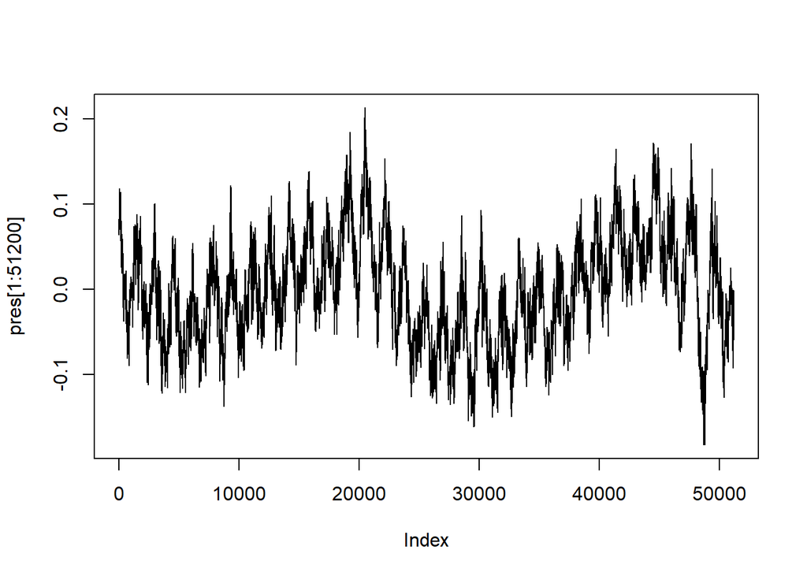

```r
## Noise data -------------------------------------------------------------------
# Hanning window --------------------------------
hann_win = matrix(,t_sel,1)
for (i in 1:t_sel[1]) {
  hann_win[i,1] <- 0.5-0.5*cos(2*pi*(i-1)/t_sel)
}
#------------------------------------------------
plot(pres[1:51200],type='line')    #음압 시간 데이터
```

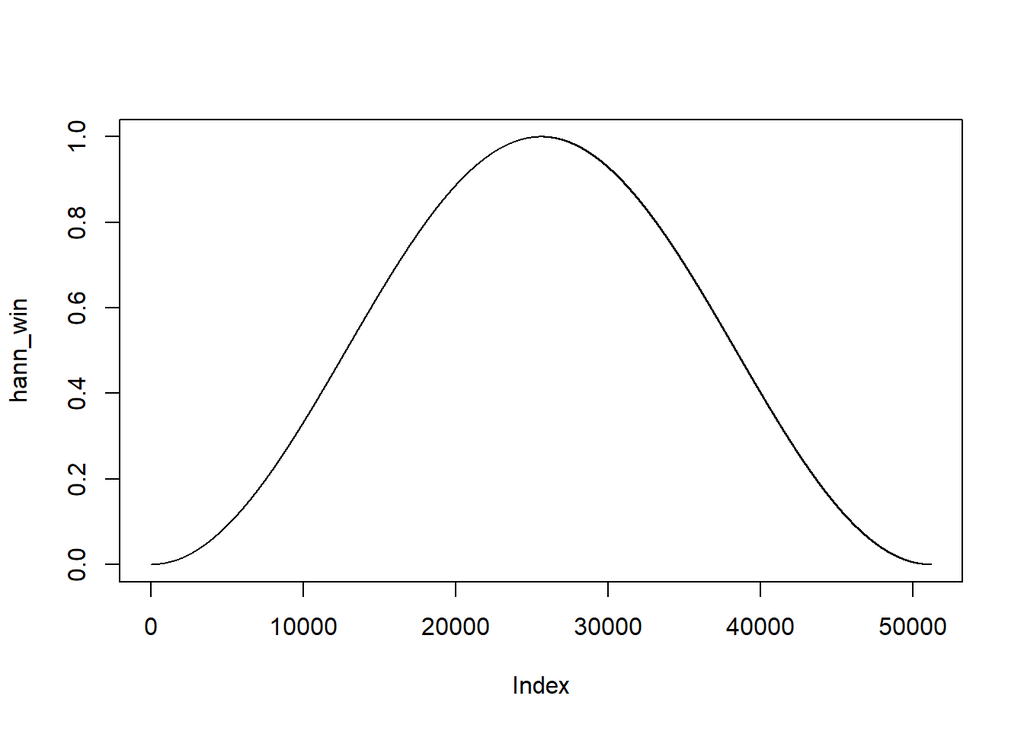

```r
plot(hann_win,type='line')         # Hanning window 그래프
```

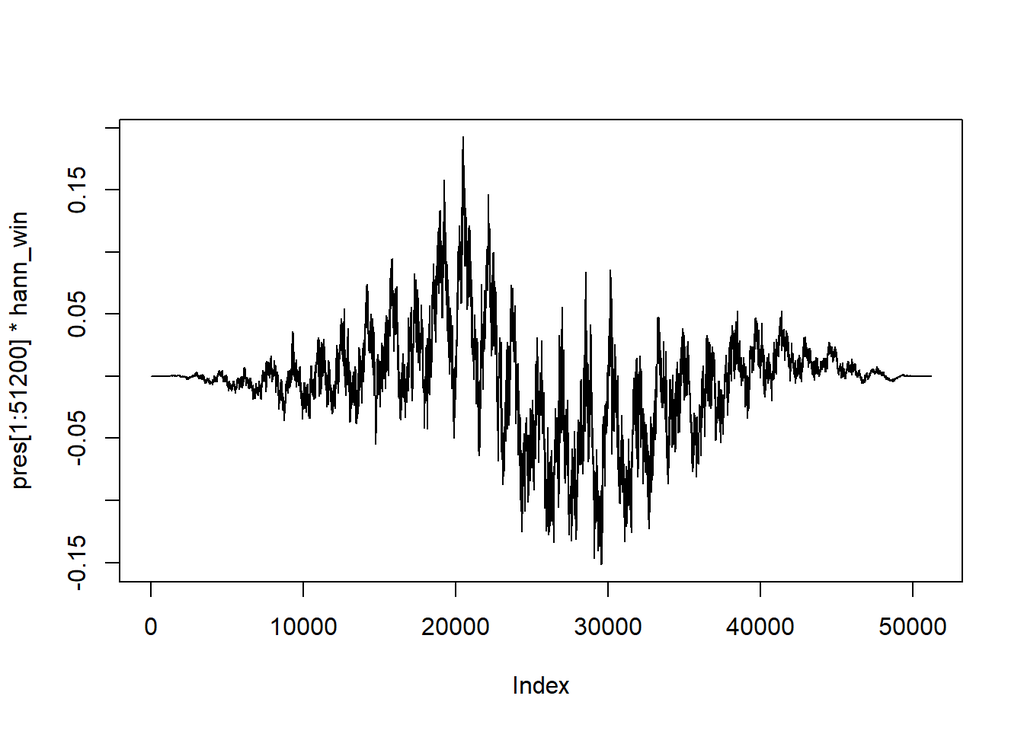

```r
plot(pres[1:51200]*hann_win,type='line')  # 음압 데이터에 hanning window 적용한 시간 데이터
```

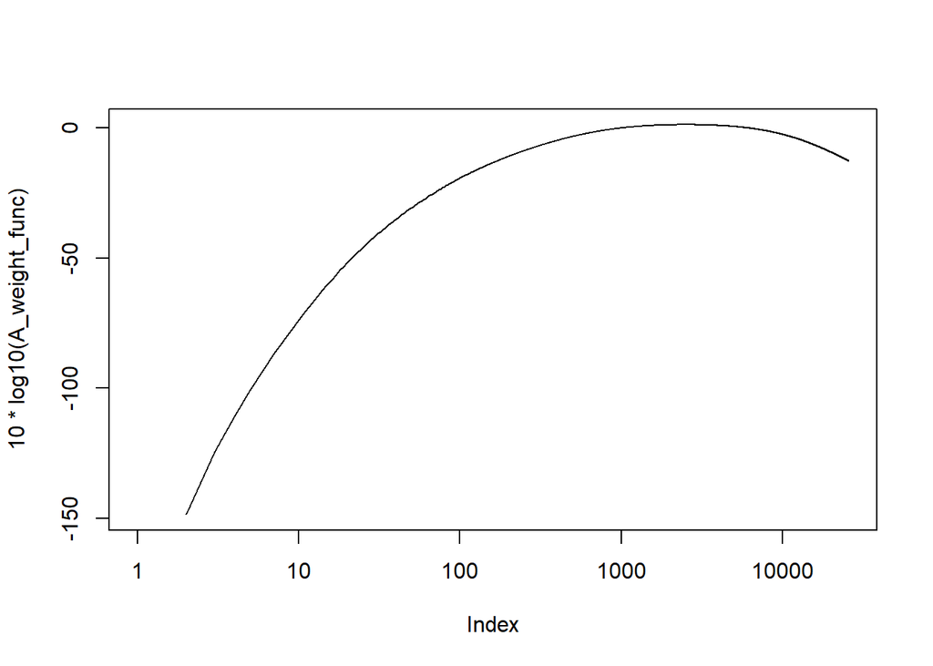

```r
# A weighting 함수 ------------------------------------------------------------------
A_weighting <- function(max_f, df) {
  f <- seq(from=0, to=max_f-1, by=df)
  Ra_f <- 12194^2*f^4/((f^2+20.6^2)*(f^2+12194^2)*sqrt((f^2+107.7^2)*(f^2+737.9^2)))
  Ra_f1000 <- 12194^2*1000^4/((1000^2+20.6^2)*(1000^2+12194^2)*sqrt((1000^2+107.7^2)*(1000^2+737.9^2)))
  A_fdB <- 20*log10(Ra_f)-20*log10(Ra_f1000)
  s_f <- Ra_f^2/Ra_f1000^2
  return(s_f)
}
A_weight_func <- A_weighting(max_f, df)
plot(10*log10(A_weight_func), type="line", log="x")           # A-weighting 함수 (dB 단위)
```

```r
#------------------------------------------------------------------------------------

avg_num <- 30
# overlab 67%
overlab <- 0.67
overlab_num <- round(overlab*t_sel,0)

# for 문 돌려서 각 샘플 추출
#--------------------------------------
sta = 1
fin = t_sel

t_raw <- data.frame()
FT <- data.frame()
FT_A <- data.frame()

for (i in 1:30) {
  t_raw[1:51200,i] <- pres[sta:fin,1]*hann_win
  FT[1:51200,i] <- 2*abs(fft(t_raw[1:51200,i]))/(sqrt(2)*t_sel[1])
  FT_A[1:25600,i] <- FT[1:25600,i]*A_weight_func
  LFT <- 10*log10(FT_A^2/0.00002^2)
  sta <- fin-overlab_num+1
  fin <- sta+t_sel-1
}
#-----------------------------------------------------------------------------

# MV data
#-----------------------------------------------------------------------------
mv_re <- select(mv1, c("INV", "FAN 현재", "FAN2 현재", "Main EEV", "공기온도", "흡입온도", "INV 토출온도", "열교환기온도"))
mv_re
```

```
##       INV FAN 현재 FAN2 현재 Main EEV 공기온도 흡입온도 INV 토출온도
##    1:   0        0         0        0     17.6     18.8           20
##    2:   0        0         0        0     17.6     18.8           20
##    3:   0        0         0        0     17.6     18.8           20
##    4:   0        0         0        0     17.6     18.8           20
##    5:   0        0         0        0     17.6     18.8           20
##   ---
## 1013:   0        0         0       50      8.8     -1.4           63
## 1014:   0        0         0       50      8.7     -1.2           62
## 1015:   0        0         0       50      8.7     -0.9           62
## 1016:   0        0         0       50      8.7     -0.8           62
## 1017:   0        0         0       50      8.7     -0.6           62
##       열교환기온도
##    1:         18.0
##    2:         18.0
##    3:         18.0
##    4:         18.0
##    5:         17.7
##   ---
## 1013:         -0.2
## 1014:         -0.2
## 1015:          0.1
## 1016:          0.1
## 1017:          0.1
```

```r
r_ch <- seq(500, 1000, length=30)
mv_sel <- slice(mv_re, r_ch)

mv_sel$INV <- c("V1","V2","V3","V4","V5","V6","V7","V8","V9","V10","V11","V12","V13","V14","V15","V16","V17","V18","V19","V20","V21","V22","V23","V24","V25","V26","V27","V28","V29","V30")

# MV 데이터 저장
#library(writexl)

#write_xlsx(mv_sel,"./output/MV_DB.xlsx",col_names=TRUE)
```

### 5. 시각화

- **소음 스펙트럼**

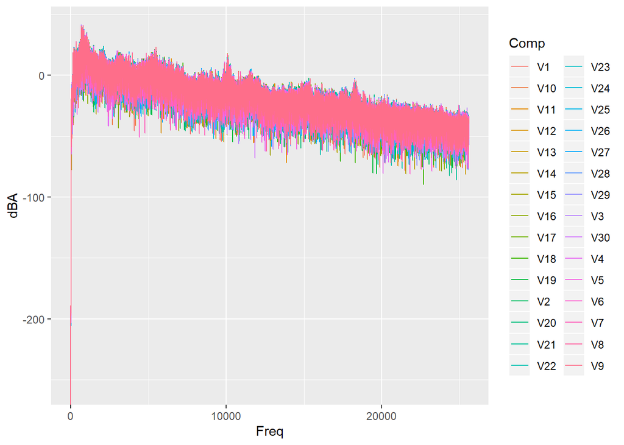

```r
d = data.frame(d_f)

gFT_A <- tidyr::gather(data=LFT, V1:V30, key="Comp", value="dBA")
library(magrittr)
library(dplyr)
gFT_A %<>%
  mutate(Freq=rep(1:25600, times=30))
library(ggplot2)
g <- gFT_A %>% ggplot(aes(x=Freq, y=dBA, group=Comp))
g + geom_line(aes(group=Comp, color=Comp))
```

### 6. 향후 계획

1. **추후 필요 업무**
- DB파일 접속 및 관심 조건에서의 스펙트럼 및 필요정보 확인용 GUI 생성
- FFT 데이터 cross check 및 DB 업데이트 코딩 완성
- MV data 추출 데이터 확정
- 필요시 산학과제로 진행 필요
2. **과제 완성시 기대효과**
- 소음 인정시험 데이터 DB화 가능
- 데이터가 충분히 쌓이면 빅데이터 분석을 통한 소음 개선 가능
3. **개인 소감**
- 빅데이터 교육 및 과제 진행을 통해 미래 자동화&지능화에 대한 비전을 확인할 수 있는 기회가 되었습니다.
- 아직까지는 분명한 한계도 있었지만 따라서 미래를 선도하려면 이 분야에 더 집중하고 활성화해야 할 필요성도 느낄 수 있었습니다.